# 2016 Election Analysis

Phillip Kim (PSTAT 131), Syen Yang Lu (PSTAT 231)

Due June 13, 2018, midnight

# Background

Predicting voter behavior is complicated for many reasons despite the tremendous effort in collecting, analyzing, and understanding many available datasets. For our final project, we will analyze the 2016 presidential election dataset.

The presidential election in 2012 did not come as a surprise to most. Many analysts predicted the outcome of the election correctly including [Nate Silver](https://en.wikipedia.org/wiki/Nate_Silver). There has been some [speculation about his approach](https://www.theguardian.com/science/grrlscientist/2012/nov/08/nate-sliver-predict-us-election).

Despite largely successful predictions in 2012, the 2016 presidential election was [more surprising](https://fivethirtyeight.com/features/the-polls-missed-trump-we-asked-pollsters-why/).

1. What makes predicting voter behavior (and thus election forecasting) a hard problem?
- Election forecasting can be difficult, the level of difficulty depending on when the forecasting happens. For instance, if one were to predict voting behavior months before the poll data comes through, there are a lot of changes to the voting behavior that is to happen as time passes when, say, a candidate decides to propose doubling federal income tax. Also, analyzing voting behavior at a state level versus a national level can be challenging as well. Because voting behavior is constantly changing, there is much forecasting to be done, especially if one were to try to make inferences in early voting. There are also things that are not measurable, such as the decisions the presidents make and the effects the decisions would have on the economy, success of advertisements. The success and appeal of the speeches presidents make and the success of the advertisements for their campaign isn’t something that are measurable. The success of these speeches and advertisements, however, are things which can heavily affect voting behavior and because they are not measurable, it is difficult to predict voting behavior. There are also a lot of variables to keep track of when making such forecasts.
2. Although Nate Silver predicted that Clinton would win 2016, [he gave Trump higher odds than most](http://fivethirtyeight.com/features/why-fivethirtyeight-gave-trump-a-better-chance-than-almost-anyone-else/). What is unique about Nate Silver’s methodology?
- Nate Silver’s methodology takes into account small systematic polling errors, which most people do not take note of since most mistake the idea of having large volume of polling data leading to elimination of uncertainty and risks. He also assumes that polling errors are correlated. In other words, if polls miss in one direction in one state, then they often also miss in the same direction in other states. Although Silver had taken into polling error, most thought that there was massive polling error; however, Silver thought otherwise and states that there was a modest polling error. Silver also considers portion of third party voters, in which 3% of voters in 2012 were third-party voters while there were 12% of voters in 2016. In addition, Silver doesn’t make inferences from early voting, despiting having received criticisms from many reporters and pundits, and believes that it’s hard to make inferences from early voting and doing so has had a bad tracking record.
3. Discuss why analysts believe predictions were less accurate in 2016. Can anything be done to make future predictions better? What are some challenges for predicting future elections? How do you think journalists communicate results of election forecasting models to a general audience?
- Analysts believed that that predictions were less accurate in 2016 because of polling error. Some of the challenges were getting people to be comfortable with sharing who they were voting for. It’s stated that women who voted for Trump might have been reluctant to tell the pollsters. Pollsters, however, still decided to ignore the discomfort that people feel when they are voting for Trump. Perhaps from now on, people could be presented with the option to communicate their vote through a recorded voice and that there could be more accredited methods towards providing such voices. Journalists ultimately still acknowledged that Clinton had more national popular votes than Trump and that she might’ve lost due to small polling errors, presenting the possibiity that Clinton might have been able to win the election had it not been for the polling error.

# Data

## Election data

Following is the first few rows of the `election.raw` data:

| county | fips | candidate | state | votes |
| --- | --- | --- | --- | --- |
| NA | US | Donald Trump | US | 62984825 |
| NA | US | Hillary Clinton | US | 65853516 |
| NA | US | Gary Johnson | US | 4489221 |
| NA | US | Jill Stein | US | 1429596 |
| NA | US | Evan McMullin | US | 510002 |
| NA | US | Darrell Castle | US | 186545 |

The meaning of each column in `election.raw` is clear except `fips`. The acronym is short for [Federal Information Processing Standard](https://en.wikipedia.org/wiki/FIPS_county_code).

In our dataset, `fips` values denote the area (US, state, or county) that each row of data represent: i.e., some rows in `election.raw` are summary rows. These rows have `county` value of `NA`. There are two kinds of summary rows:

- Federal-level summary rows have `fips` value of `US`.
- State-level summary rows have names of each states as `fips` value.

## Census data

Following is the first few rows of the `census` data:

| CensusTract | State | County | TotalPop | Men | Women | Hispanic | White | Black | Native | Asian | Pacific | Citizen | Income | IncomeErr | IncomePerCap | IncomePerCapErr | Poverty | ChildPoverty | Professional | Service | Office | Construction | Production | Drive | Carpool | Transit | Walk | OtherTransp | WorkAtHome | … |
| --- | --- | --- | --- | --- | --- | --- | --- | --- | --- | --- | --- | --- | --- | --- | --- | --- | --- | --- | --- | --- | --- | --- | --- | --- | --- | --- | --- | --- | --- | --- |
| 1001020100 | Alabama | Autauga | 1948 | 940 | 1008 | 0.9 | 87.4 | 7.7 | 0.3 | 0.6 | 0.0 | 1503 | 61838 | 11900 | 25713 | 4548 | 8.1 | 8.4 | 34.7 | 17.0 | 21.3 | 11.9 | 15.2 | 90.2 | 4.8 | 0 | 0.5 | 2.3 | 2.1 | … |
| 1001020200 | Alabama | Autauga | 2156 | 1059 | 1097 | 0.8 | 40.4 | 53.3 | 0.0 | 2.3 | 0.0 | 1662 | 32303 | 13538 | 18021 | 2474 | 25.5 | 40.3 | 22.3 | 24.7 | 21.5 | 9.4 | 22.0 | 86.3 | 13.1 | 0 | 0.0 | 0.7 | 0.0 | … |
| 1001020300 | Alabama | Autauga | 2968 | 1364 | 1604 | 0.0 | 74.5 | 18.6 | 0.5 | 1.4 | 0.3 | 2335 | 44922 | 5629 | 20689 | 2817 | 12.7 | 19.7 | 31.4 | 24.9 | 22.1 | 9.2 | 12.4 | 94.8 | 2.8 | 0 | 0.0 | 0.0 | 2.5 | … |
| 1001020400 | Alabama | Autauga | 4423 | 2172 | 2251 | 10.5 | 82.8 | 3.7 | 1.6 | 0.0 | 0.0 | 3306 | 54329 | 7003 | 24125 | 2870 | 2.1 | 1.6 | 27.0 | 20.8 | 27.0 | 8.7 | 16.4 | 86.6 | 9.1 | 0 | 0.0 | 2.6 | 1.6 | … |
| 1001020500 | Alabama | Autauga | 10763 | 4922 | 5841 | 0.7 | 68.5 | 24.8 | 0.0 | 3.8 | 0.0 | 7666 | 51965 | 6935 | 27526 | 2813 | 11.4 | 17.5 | 49.6 | 14.2 | 18.2 | 2.1 | 15.8 | 88.0 | 10.5 | 0 | 0.0 | 0.6 | 0.9 | … |
| 1001020600 | Alabama | Autauga | 3851 | 1787 | 2064 | 13.1 | 72.9 | 11.9 | 0.0 | 0.0 | 0.0 | 2642 | 63092 | 9585 | 30480 | 7550 | 14.4 | 21.9 | 24.2 | 17.5 | 35.4 | 7.9 | 14.9 | 82.7 | 6.9 | 0 | 0.0 | 6.0 | 4.5 | … |

### Census data: column metadata

Column information is given in `metadata`.

[output not shown]

## Data wrangling

4. Remove summary rows from `election.raw` data:

Following is the first few rows of the `election_federal` data:

| county | fips | candidate | state | votes |
| --- | --- | --- | --- | --- |
| NA | US | Donald Trump | US | 62984825 |
| NA | US | Hillary Clinton | US | 65853516 |
| NA | US | Gary Johnson | US | 4489221 |
| NA | US | Jill Stein | US | 1429596 |
| NA | US | Evan McMullin | US | 510002 |
| NA | US | Darrell Castle | US | 186545 |

Following is the first few rows of the `election_state` data:

| county | fips | candidate | state | votes |
| --- | --- | --- | --- | --- |
| NA | CA | Hillary Clinton | CA | 8753788 |
| NA | CA | Donald Trump | CA | 4483810 |
| NA | CA | Gary Johnson | CA | 478500 |
| NA | CA | Jill Stein | CA | 278657 |
| NA | CA | Gloria La Riva | CA | 66101 |
| NA | FL | Donald Trump | FL | 4617886 |

Following is the first few rows of the `election` data:

| county | fips | candidate | state | votes |
| --- | --- | --- | --- | --- |
| Los Angeles County | 6037 | Hillary Clinton | CA | 2464364 |
| Los Angeles County | 6037 | Donald Trump | CA | 769743 |
| Los Angeles County | 6037 | Gary Johnson | CA | 88968 |
| Los Angeles County | 6037 | Jill Stein | CA | 76465 |
| Los Angeles County | 6037 | Gloria La Riva | CA | 21993 |
| Cook County | 17031 | Hillary Clinton | IL | 1611946 |

5. How many named presidential candidates were there in the 2016 election? Draw a bar chart of all votes received by each candidate

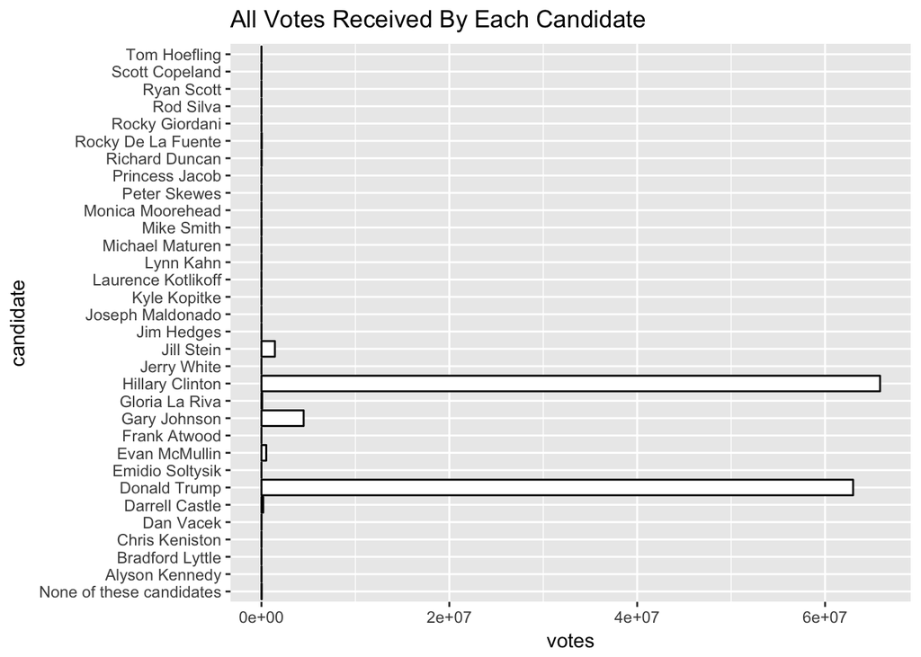

6. Create variables `county_winner` and `state_winner` by taking the candidate with the highest proportion of votes.

Following is the first few rows of the `county_winner` data:

| county | fips | candidate | state | votes | total | pct |
| --- | --- | --- | --- | --- | --- | --- |
| Los Angeles County | 6037 | Hillary Clinton | CA | 2464364 | 135379666 | 0.0182034 |
| Cook County | 17031 | Hillary Clinton | IL | 1611946 | 135379666 | 0.0119069 |
| Maricopa County | 4013 | Donald Trump | AZ | 747361 | 135379666 | 0.0055205 |
| Harris County | 48201 | Hillary Clinton | TX | 707914 | 135379666 | 0.0052291 |
| San Diego County | 6073 | Hillary Clinton | CA | 735476 | 135379666 | 0.0054327 |
| Orange County | 6059 | Hillary Clinton | CA | 609961 | 135379666 | 0.0045056 |

Following is the first few rows of the `state_winner` data:

| county | fips | candidate | state | votes | total | pct |
| --- | --- | --- | --- | --- | --- | --- |
| NA | CA | Hillary Clinton | CA | 8753788 | 136004290 | 0.0643641 |
| NA | FL | Donald Trump | FL | 4617886 | 136004290 | 0.0339540 |
| NA | TX | Donald Trump | TX | 4685047 | 136004290 | 0.0344478 |
| NA | NY | Hillary Clinton | NY | 4556124 | 136004290 | 0.0334999 |
| NA | PA | Donald Trump | PA | 2970733 | 136004290 | 0.0218429 |
| NA | IL | Hillary Clinton | IL | 3090729 | 136004290 | 0.0227252 |

# Visualization

Visualization is crucial for gaining insight and intuition during data mining. We will map our data onto maps.

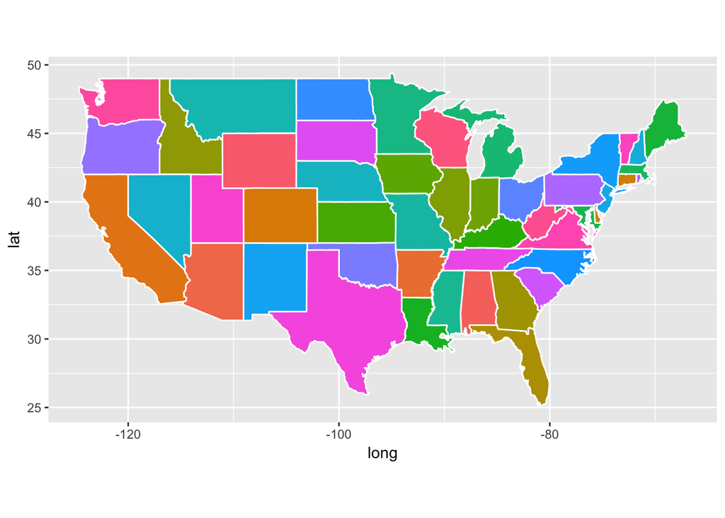

7. Draw county-level map, colored by county

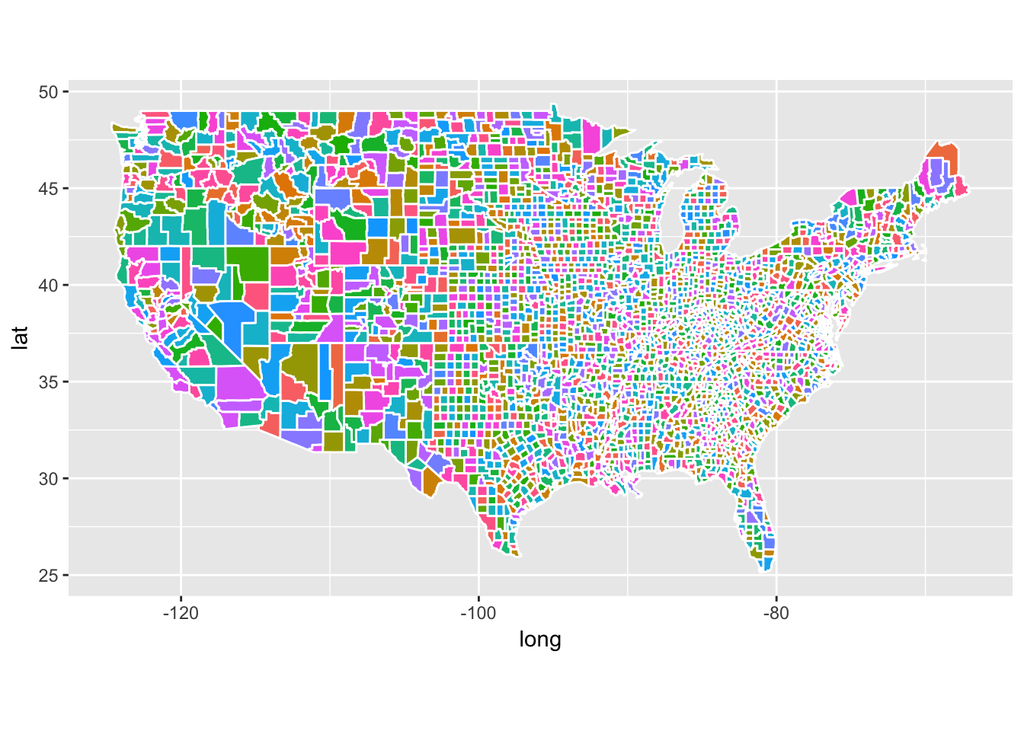

8. Now color the map by the winning candidate for each state.

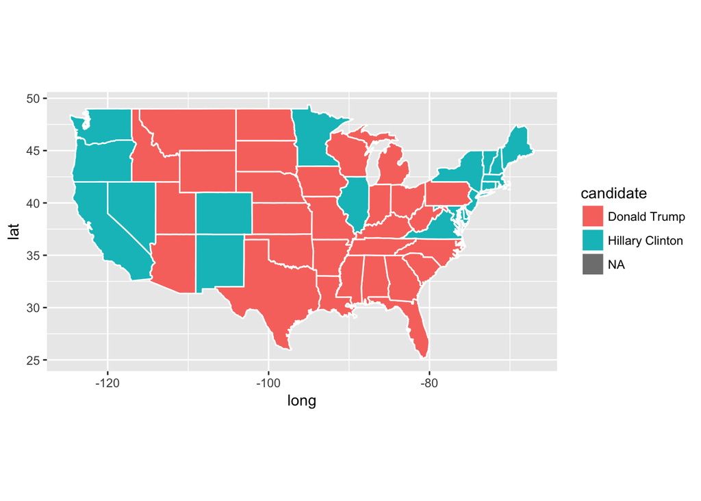

9. Color the map by the winning candidate for each county.

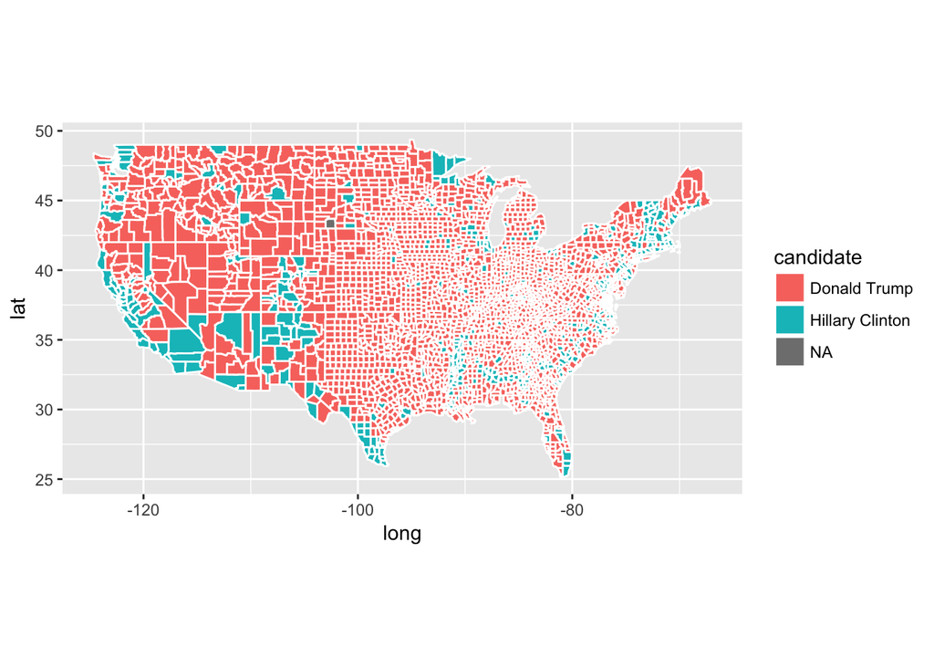

10. Create a visualization of your choice using `census` data.

Following is the visualization of map by majority of gender for each state:

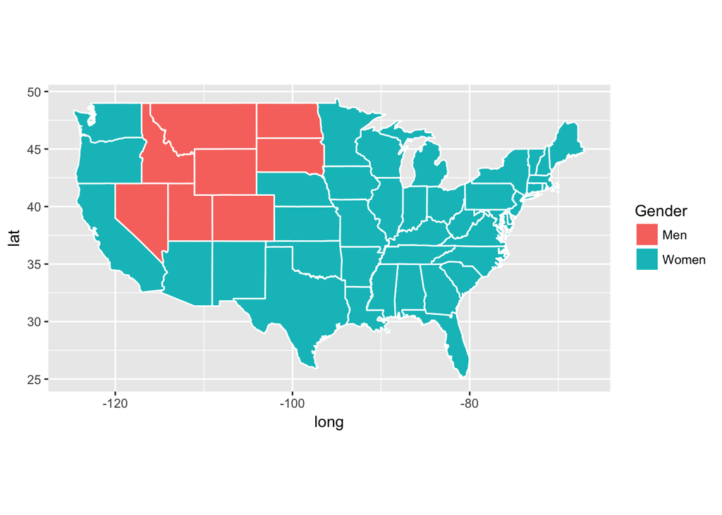

11. The `census` data contains high resolution information (more fine-grained than county-level).

    In this problem, we aggregate the information into county-level data by computing weighted average of each attributes for each county.

    Create the following variables:
    - *Clean census data `census.del`*
    - *Sub-county census data, `census.subct`*
    - *County census data, `census.ct`*

Following is the first few rows of the `census.ct` data:

| State | County | TotalPop | Men | White | Citizen | Income | IncomeErr | IncomePerCap | IncomePerCapErr | Poverty | ChildPoverty | Professional | Service | Office | Production | Drive | Carpool | Transit | OtherTransp | WorkAtHome | MeanCommute | Employed | PrivateWork | SelfEmployed | FamilyWork | Unemployment | Minority |
| --- | --- | --- | --- | --- | --- | --- | --- | --- | --- | --- | --- | --- | --- | --- | --- | --- | --- | --- | --- | --- | --- | --- | --- | --- | --- | --- | --- |
| Alabama | Autauga | 29848810 | 222875.0 | 348758.47 | 339375.0 | 237893387 | 35760241 | 114926404 | 15800911 | 59419.20 | 86087.61 | 150895.87 | 79014.09 | 111741.67 | 78952.83 | 402681.8 | 40409.05 | 438.3583 | 6009.742 | 8447.217 | 121947.1 | 199883.33 | 339316.9 | 25002.47 | 0.0000 | 35588.68 | 103709.04 |
| Alabama | Baldwin | 48458973 | 307464.5 | 523066.63 | 476435.5 | 321473552 | 55043318 | 171938329 | 23941460 | 84495.14 | 122638.62 | 206009.65 | 112987.15 | 170601.14 | 71262.33 | 532482.7 | 56390.46 | 796.9806 | 9087.603 | 24235.774 | 165677.7 | 277267.74 | 511611.4 | 37194.80 | 2286.8613 | 47772.04 | 95761.99 |
| Alabama | Barbour | 9950462 | 161077.8 | 138345.48 | 230155.6 | 98628875 | 18047627 | 50345533 | 7272206 | 79316.62 | 130349.74 | 78174.74 | 49265.91 | 69660.44 | 69776.06 | 249361.0 | 33086.29 | 1482.4667 | 4852.922 | 4494.489 | 73369.6 | 95522.22 | 214241.8 | 21395.49 | 268.6444 | 52444.26 | 155438.99 |
| Alabama | Bibb | 36057436 | 301825.0 | 420998.88 | 437375.0 | 219748374 | 31997986 | 104153526 | 17368908 | 93827.77 | 153690.73 | 122005.65 | 101466.25 | 98707.75 | 134178.17 | 471490.5 | 74331.23 | 2843.2250 | 8827.400 | 4133.525 | 162265.0 | 207350.00 | 433679.5 | 37510.97 | 2227.3500 | 46129.70 | 136561.90 |
| Alabama | Blount | 45004651 | 316800.0 | 563338.43 | 470500.0 | 296488132 | 55759313 | 131657508 | 13158235 | 107222.09 | 172215.47 | 182936.22 | 89402.53 | 152847.66 | 128912.17 | 544079.0 | 72324.88 | 2325.2778 | 2692.756 | 14526.333 | 223433.2 | 246544.44 | 524691.0 | 27115.47 | 2285.9111 | 49371.80 | 67935.86 |
| Alabama | Bullock | 15174189 | 188666.7 | 79014.27 | 268566.7 | 118499782 | 32035227 | 62571537 | 11071822 | 87212.93 | 132731.67 | 69593.97 | 53120.20 | 71793.57 | 91601.13 | 266141.2 | 52817.40 | 2752.1333 | 6491.600 | 11033.500 | 101907.5 | 128833.33 | 281510.0 | 18770.80 | 0.0000 | 63676.57 | 272416.67 |

# Dimensionality reduction

12. Run PCA for both county & sub-county level data.

Save the first two principle components PC1 and PC2 into a two-column data frame, call it `ct.pc` and `subct.pc`, respectively. Discuss whether you chose to center and scale the features before running PCA and the reasons for your choice.

- We chose to center and scale the features before running PCA because the variables might have different variances and do not have a mean of zero. If we failed to scale the variables before performing PCA, then most of the principal components that we observed would be driven by the variable that has the largest mean and variance. If mean is not zero, usually the first PC direction will point toward the mean. Thus, it is important to standardize the variables to have mean zero and standard deviation one before performing PCA.

What are the features with the largest absolute values in the loadings matrix?

- OtherTransp has the largest absolute value in the loadings matrix for `ct.prcomp`.
- FamilyWork has the largest absolute value in the loadings matrix for `subct.prcomp`.
13. Determine the number of minimum number of PCs needed to capture 90% of the variance for both the county and sub-county analyses.
- We need minimum of 8 PCs in order to capture 90% of the variance for both the county analysis.
- We need minimum of 15 PCs in order to capture 90% of the variance for both the sub-county analysis.

Plot proportion of variance explained (PVE) and cumulative PVE for both county and sub-county analyses.

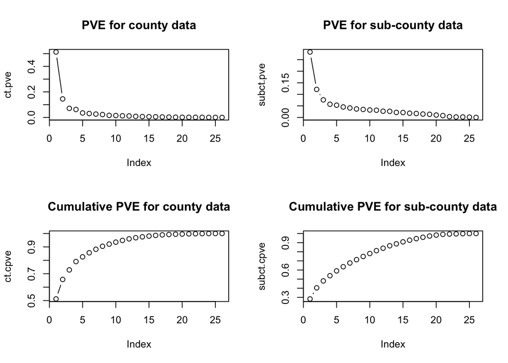

# Clustering

14. With `census.ct`, perform hierarchical clustering with complete linkage. Cut the tree to partition the observations into 10 clusters. Re-run the hierarchical clustering algorithm using the first 5 principal components of **`ct.prcomp`** as inputs instead of the original features.

Following is the first few rows of the `all.table` data that contains the observations in each cluster for each respective method:

| ct.table | pc.table |
| --- | --- |
| 1028 | 1827 |
| 315 | 104 |
| 830 | 1052 |
| 947 | 169 |
| 66 | 2 |
| 2 | 1 |
| 22 | 42 |
| 6 | 5 |
| 1 | 1 |
| 1 | 15 |

Following is the first few rows of the `common.table` data that contains the observations in each cluster for both methods:

| 1 | 2 | 3 | 4 | 5 | 6 | 7 | 8 | 9 | 10 |
| --- | --- | --- | --- | --- | --- | --- | --- | --- | --- |
| 920 | 26 | 59 | 14 | 2 | 1 | 5 | 0 | 0 | 1 |
| 262 | 42 | 5 | 0 | 0 | 0 | 6 | 0 | 0 | 0 |
| 52 | 0 | 669 | 100 | 0 | 0 | 0 | 0 | 0 | 9 |
| 564 | 1 | 319 | 55 | 0 | 0 | 3 | 0 | 0 | 5 |
| 28 | 23 | 0 | 0 | 0 | 0 | 15 | 0 | 0 | 0 |
| 0 | 0 | 0 | 0 | 0 | 0 | 1 | 0 | 1 | 0 |
| 1 | 10 | 0 | 0 | 0 | 0 | 10 | 1 | 0 | 0 |
| 0 | 2 | 0 | 0 | 0 | 0 | 2 | 2 | 0 | 0 |
| 0 | 0 | 0 | 0 | 0 | 0 | 0 | 1 | 0 | 0 |
| 0 | 0 | 0 | 0 | 0 | 0 | 0 | 1 | 0 | 0 |

Compare and contrast the results.

- We can see from the above tables that the two clustering methods have put a total of 1698 observations in their same respective clusters while 1520 observations are placed in different clusters when viewing each of the clustering methods. Both clustering methods seem to favor putting most of their observations in the first and 3rd cluster, while the clustering method using original features places more observations in the fourth cluster than the other method does.

For both approaches investigate the cluster that contains San Mateo County.

Following is the observation of San Mateo County in the `census.ct` data:

| State | County | TotalPop | Men | White | Citizen | Income | IncomeErr | IncomePerCap | IncomePerCapErr | Poverty | ChildPoverty | Professional | Service | Office | Production | Drive | Carpool | Transit | OtherTransp | WorkAtHome | MeanCommute | Employed | PrivateWork | SelfEmployed | FamilyWork | Unemployment | Minority |
| --- | --- | --- | --- | --- | --- | --- | --- | --- | --- | --- | --- | --- | --- | --- | --- | --- | --- | --- | --- | --- | --- | --- | --- | --- | --- | --- | --- |
| California | San Mateo | 26138249 | 236805.8 | 195607.3 | 309019.4 | 483115407 | 77605712 | 230469320 | 29436282 | 38560.32 | 46716.02 | 220141.6 | 88035.12 | 107356.9 | 35345.82 | 336583.7 | 51413.47 | 44557.56 | 12508.97 | 24441.97 | 129126.8 | 248970.3 | 383943.3 | 40275.84 | 826.0632 | 32198.81 | 267304.7 |

Which approach seemed to put San Mateo County in a more appropriate clusters? Comment on what you observe and discuss possible explanations for these observations.

- Euclidean Distance between centroid and San Mateo point in clustering method using original features is 5.216364310^{6}
- Euclidean Distance between centroid and San Mateo point in clustering method using PC’s is 6.838781910^{6}.
- The cluster of the original features contains only 66 observations and the cluster of the PC’s contains 1827 observations. So, we standardize the Euclidean distance by using the number of counties in each cluster.
- Because the standardized Euclidean distance between the centroid and San Mateo of the method using original features is less than that of the method using PC’s, the approach with original features seem to put San Mateo County in a more appropriate cluster.

# Classification

In order to train classification models, we need to merge `county_winner` and `census.ct` data into `election.cl` for classification.

Following is the first few rows of the `election.cl` data:

| candidate | TotalPop | Men | White | Citizen | Income | IncomeErr | IncomePerCap | IncomePerCapErr | Poverty | ChildPoverty | Professional | Service | Office | Production | Drive | Carpool | Transit | OtherTransp | WorkAtHome | MeanCommute | Employed | PrivateWork | SelfEmployed | FamilyWork | Unemployment | Minority |
| --- | --- | --- | --- | --- | --- | --- | --- | --- | --- | --- | --- | --- | --- | --- | --- | --- | --- | --- | --- | --- | --- | --- | --- | --- | --- | --- |
| Hillary Clinton | 21027757 | 213727.7 | 116896.8 | 261217.1 | 266643126 | 45921306 | 123317523 | 17382602 | 79206.98 | 102132.42 | 147712.3 | 84710.10 | 107171.75 | 59344.80 | 316670.2 | 44606.60 | 30198.48 | 9643.287 | 21336.08 | 130947.9 | 201091.0 | 343686.5 | 39924.93 | 684.5320 | 44022.53 | 306925.2 |
| Hillary Clinton | 19261078 | 193225.4 | 171818.0 | 266525.0 | 238561109 | 41098102 | 123678014 | 17601906 | 68260.61 | 89638.92 | 143120.9 | 76785.46 | 97967.83 | 55542.46 | 250008.3 | 35656.59 | 72622.17 | 8261.325 | 16200.05 | 130488.9 | 187626.1 | 332909.4 | 17878.22 | 501.9979 | 45554.80 | 220261.8 |
| Donald Trump | 22735053 | 220601.7 | 252571.5 | 292188.3 | 269928789 | 43112236 | 123775949 | 17298276 | 76971.26 | 101487.14 | 156825.8 | 84396.29 | 120063.07 | 44688.31 | 339509.8 | 50693.91 | 10990.26 | 11705.153 | 25738.18 | 114505.2 | 205347.8 | 367565.7 | 25691.49 | 688.8675 | 35423.38 | 183473.0 |
| Hillary Clinton | 39820679 | 276547.0 | 175673.8 | 318116.9 | 342815828 | 56181949 | 160787011 | 22893227 | 100030.19 | 141311.73 | 182686.6 | 99810.49 | 130569.68 | 75446.89 | 439207.5 | 63119.41 | 16397.74 | 11225.419 | 18031.30 | 157857.4 | 265902.6 | 463298.1 | 35520.67 | 835.8032 | 43046.76 | 371925.1 |
| Hillary Clinton | 34313843 | 259463.4 | 243105.1 | 343362.1 | 362121676 | 56173226 | 161958996 | 20618903 | 74979.19 | 88711.32 | 203285.5 | 104214.14 | 122650.83 | 44984.58 | 396308.2 | 49670.05 | 16090.84 | 9953.723 | 32696.89 | 130917.0 | 235680.2 | 397912.9 | 39690.53 | 831.0606 | 46327.24 | 257566.9 |
| Hillary Clinton | 33994441 | 266533.0 | 227730.3 | 338742.2 | 431287523 | 65891932 | 187679109 | 24797214 | 69878.97 | 86477.42 | 212630.7 | 95786.89 | 137351.65 | 55965.35 | 421205.0 | 53803.06 | 14160.25 | 11281.049 | 27561.90 | 144896.7 | 261507.1 | 441365.9 | 41855.93 | 957.6920 | 41292.94 | 297144.1 |

## Classification

15. Decision tree: train a decision tree. Prune tree to minimize misclassification error and perform 10-fold cross-validation. Visualize the trees before and after pruning.

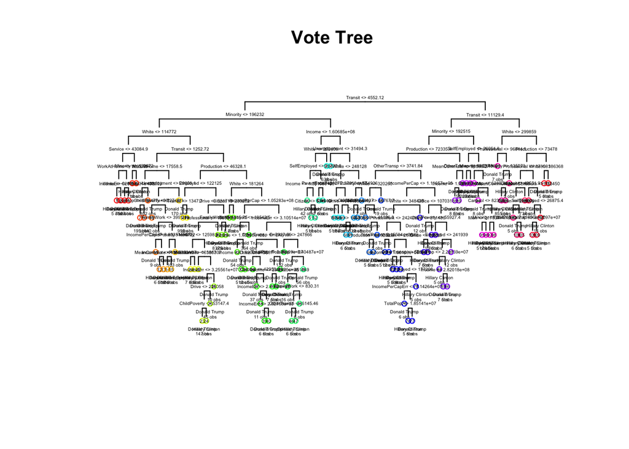

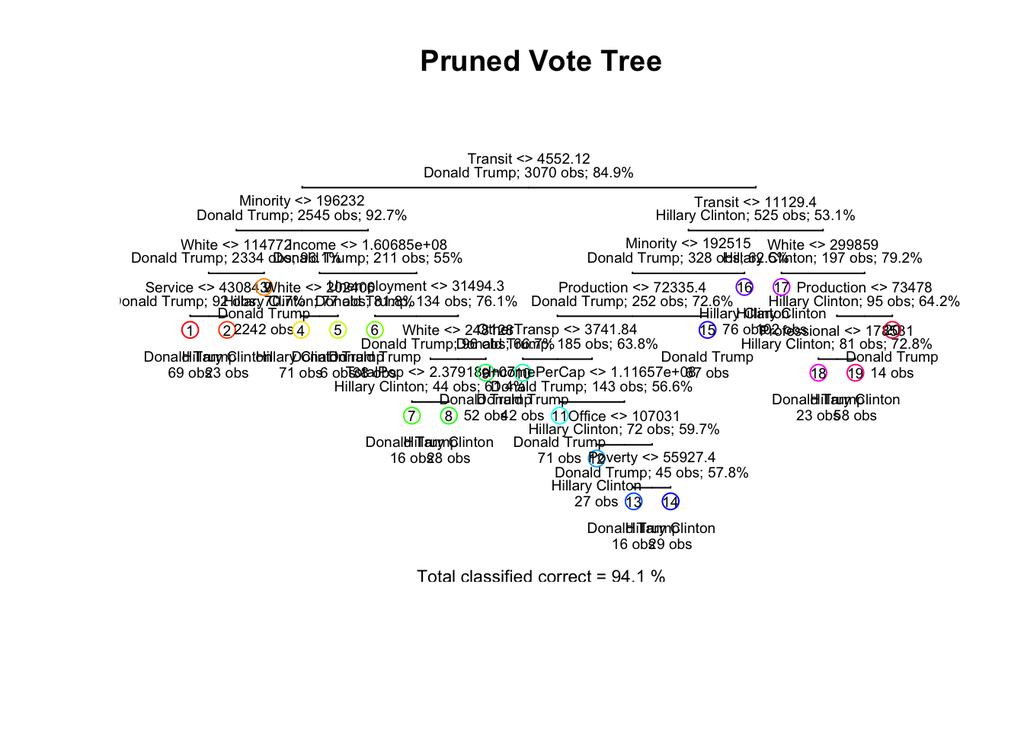

Interpret and discuss the results of the decision tree analysis.

Use this plot to tell a story about voting behavior in the US (remember the [NYT infographic?](https://archive.nytimes.com/www.nytimes.com/imagepages/2008/04/16/us/20080416_OBAMA_GRAPHIC.html))

What are the significant variables?

- At $\alpha = 0.05$, the significant variables are White, Citizen, Income, IncomePerCap, Professional, Service, Office, Production, Drive, Carpool, WorkAtHome, MeanCommute, Employed, PrivateWork, Unemployment.

Interpret the meaning of a couple of the significant coefficients.

- The variables White and Minority are the proportion of population that is white and the proportion of the population that belongs to minority. The variables Employed and Unemployment refer to the proportion of employed (over the age of 16) and unemployed.
17. When fitting logistic regression, we get a warning: `glm.fit: fitted probabilities numerically 0 or 1 occurred`.

This is an indication that we have perfect separation (some linear combination of variables *perfectly* predicts the winner), usually a sign that we are overfitting. One way to control overfitting in logistic regression is through regularization. Use the `cv.glmnet` function from the `glmnet` library to run K-fold cross validation and select the best regularization parameter for the logistic regression with LASSO penalty.

What are the non-zero coefficients in the LASSO regression for the optimal value of $\lambda$?

- For the optimal value of 6.819123910^{-5}, the non-zero coefficients are White, IncomePerCap, IncomePerCapErr, Professional, Service, Production, Carpool, Transit, OtherTransp, WorkAtHome, SelfEmployed, FamilyWork, Unemployment.

How do they compare to the unpenalized logistic regression?

- The number of variables in LASSO (13) are less than the unpenalized logistic regression (15). The interesting feature worth noting is that the variable `Transit` is non-zero in the LASSO whereas it is insignificant in the unpenalized logistic regression.
18. Compute ROC curves for the decision tree, logistic regression and LASSO logistic regression using predictions on the test data and display them on the same plot.

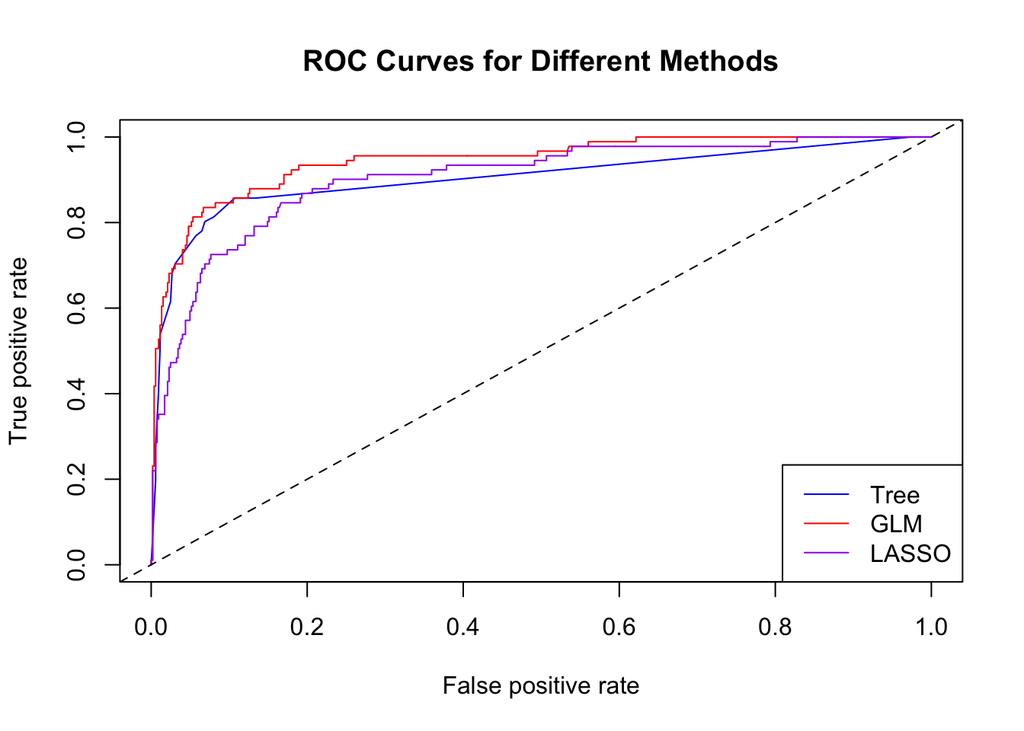

Following is the area under curve (AUC) for each method in `auc`:

| Method | Area Under Curve |
| --- | --- |
| tree | 0.903788372239615 |
| glm | 0.944246002563401 |
| lasso | 0.903273590654092 |

# Taking it further

19. Interpret and discuss any overall insights gained in this analysis and possible explanations.
- In general, there should be more variables to consider than the ones we worked with in this project. However, the methods that we have used can apply to the data with more variables.
- During the project, there were variables which we did not consider to be relevant to predicting who would win the election; however, from our calculations, we showed that variables such as `transit`, `carpool` can be relevant to predicting the winner of the election.
- From our dimensionality reduction, we found how effective PCA is in determining explanation in variances, so PCA is a efficient method in reducing the dimensionality of the data for our analysis, which also aids us in hierarchical clustering.
- Also, when calculating the misclassfication error, just because one method worked better than the other doesn’t mean that the method is superior than the other in general. The project has showed us good practice to make use of a variety of methods to determine the misclassifcation error.

We will now explore additional classification methods:

- K-Nearest Neighbors (KNN)
- Support Vector Machine (SVM)
  - Linear Kernel
  - Radial Kernel
  - Polynomial Kernel
- Boosting
- Random Forest
- Linear Discriminant Analysis (LDA)
- Quadratic Discriminant Analysis (QDA)

How do these compare to logistic regression and the tree method?

Following is the misclassification error for each method in `records` (with additional classification methods):

|  | train.error | test.error |
| --- | --- | --- |
| tree | 0.0587379 | 0.0655202 |
| glm | 0.0671824 | 0.0700326 |
| lasso | 0.0867264 | 0.1042345 |
| knn | 0.1359935 | 0.1416938 |
| svm (linear) | 0.0631107 | 0.0700326 |
| svm (radial) | 0.0382736 | 0.0635179 |
| svm (poly) | 0.0488599 | 0.0749186 |
| boost | 0.0496743 | 0.0765472 |
| rforest | 0.0008143 | 0.0765472 |
| lda | 0.0696254 | 0.0814332 |
| qda | 0.0883550 | 0.1009772 |